# Palmer Penguins

## How do penguin characteristics affect its body mass?

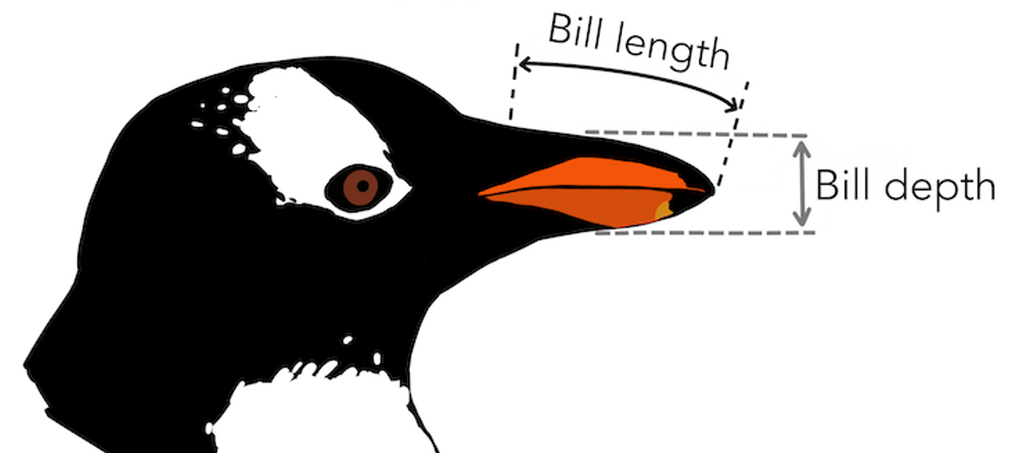

- Data has 333 rows
- Collected over 2007-2009 in Antarctica
- Categorical Features:

  **Sex, Species, Island**
- Continuous Features:

  **Bill Length, Bill Depth, Flipper Length, Body Mass**

## Plot Analysis

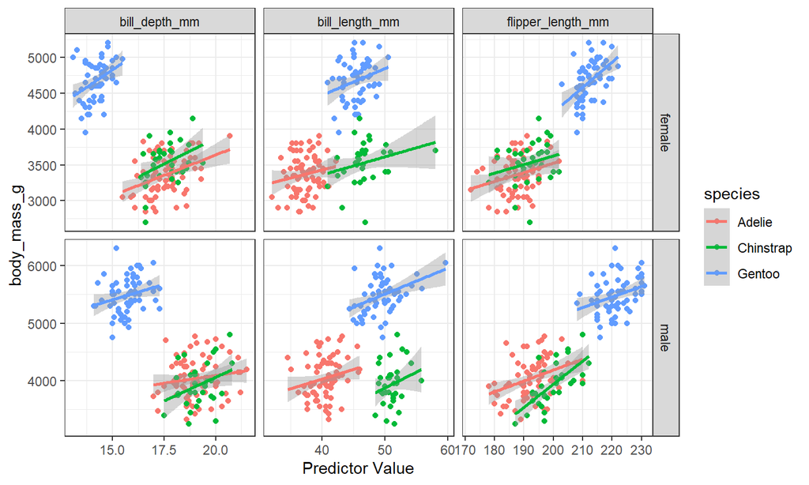

## Best Subsets Regression Result

Simple (Model A)

\[\scriptstyle \text{BodyMass } = \text{ Male } + \text{ Gentoo } + \text{ Bill Depth } + \text{ Flipper Length}\]

Complex without Interactions (Model B) \[\scriptstyle \begin{aligned} \text{BodyMass } = \text{ Male } &+ \text{ Gentoo }+\text{ Chinstrap }\\ &+\text{ Bill Length } +\text{ Bill Depth } + \text{ Flipper Length} \end{aligned}\]

Complex with Interactions (Model C) \[\scriptstyle\begin{aligned}\text{BodyMass } = \text{ Male } &+ \text{ Gentoo }+\text{ Chinstrap }\\ &+\text{ Bill Length } *\text{ Bill Depth }+\text{ Bill Length }*\text{ Flipper Length } \end{aligned}\]

## Model Comparison

### Anova \(F\)-Test \(p\)-values

- \(A\) to \(B\): 0.0087314
- \(B\) to \(C\): 0.0188342

### \(15\)-fold Cross-Validation

| Model | Mean Squared Error | Standard Error |
| --- | --- | --- |
| A | 85628.54 | 6899.618 |
| B | 84958.55 | 7240.633 |
| C | 85259.28 | 6470.569 |

## Bootstrap Confidence Intervals

Model A

```
##                   Estimated.Coefficients Lower.Bound Upper.Bound
## maleTRUE                       444.84014    347.5303    546.2287
## gentooTRUE                    1229.23800   1042.6639   1415.1893
## bill_depth_mm                   76.12165     38.0325    119.1671
## flipper_length_mm               15.78925     11.7826     20.7536
```

Model B

```
##                   Estimated.Coefficients Lower.Bound Upper.Bound
## sexmale                        389.89153  318.227340   467.30945
## speciesChinstrap              -251.47669 -386.365040  -120.09510
## speciesGentoo                 1014.62666  815.304699  1237.69595
## bill_length_mm                  18.20443    8.058091    28.59905
## bill_depth_mm                   67.21763   40.291625   106.66339
## flipper_length_mm               15.95025   10.650029    21.88062
```

## Conclusions

- Overall, the *penguins* data-set is an excellent practice for newcomers into data analysis.
- The models and plots show clear species differences and the remarkable dependence of mass on bill and flipper characteristics.
- Model C highlighted the importance of interaction terms in explaining variance, but also gives a warning about the challenges of interpretation.
- All models considered have similar predictive power.

## Thank you!

### And now, a bad joke:

#### Why did the R programmer always use a `for` loop?

#### Because they don’t know how to use a `map()`!